# Praca domowa 5

Daria Hubernatorova

11/19/2018

## Opis zadania

Celem pracy jest sprawdzenie czy ,,dobre praktyki’’ omawiane na wykładzie opracowane lata temu (słupki lepsze niż kąty, kolor wykorzystywane z umiarem, unikanie ozdobników), faktycznie działa w społeczeństwie które wykresami karmione jest od urodzenia. Wybrany rodzaj wykresu - wykres kołowy 3D. Dane pochodzą z https://www.wirtualnemedia.pl/artykul/pozeracze-mediow-szesc-typow-konsumentow

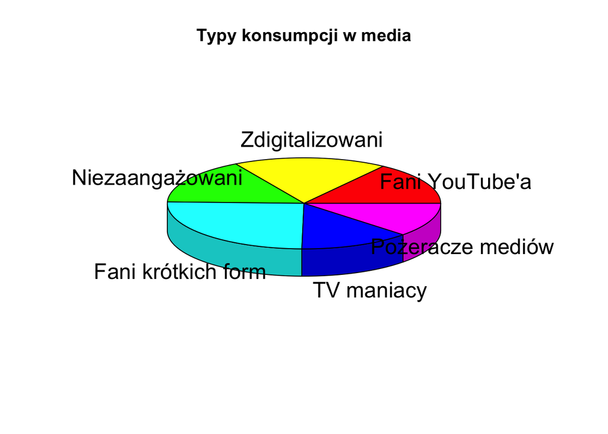

Takie dane przedstawione za pomocą wykresu słupkowego.

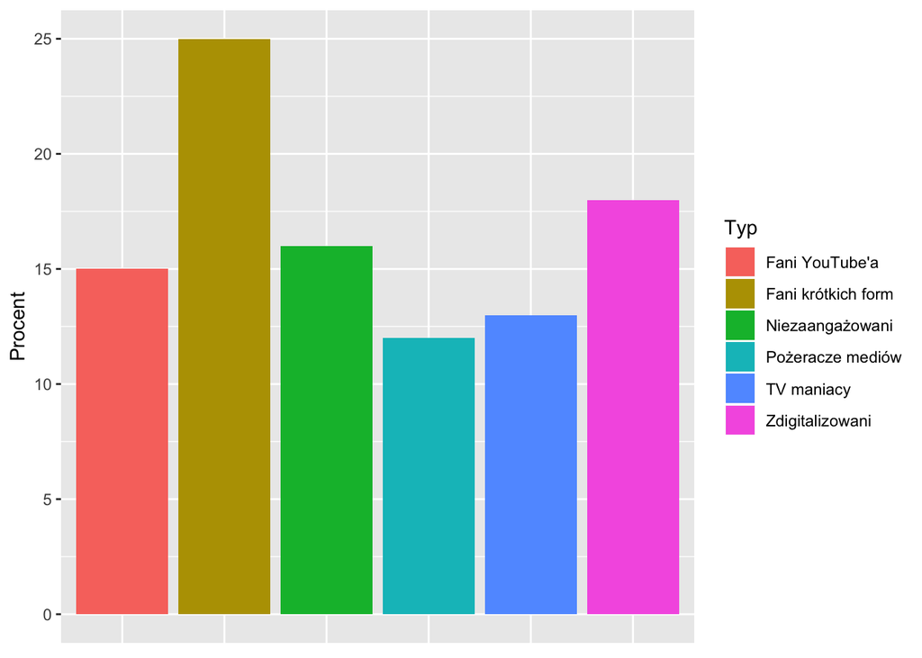

Ankieta do tego wykresu jest tutaj: https://goo.gl/forms/spgjTD1evoBgLmpz1  
Na ankietę odpowiedziało 30 osób.

## Pytanie 1

Największa grupa (typ) konsumentów mediów to:

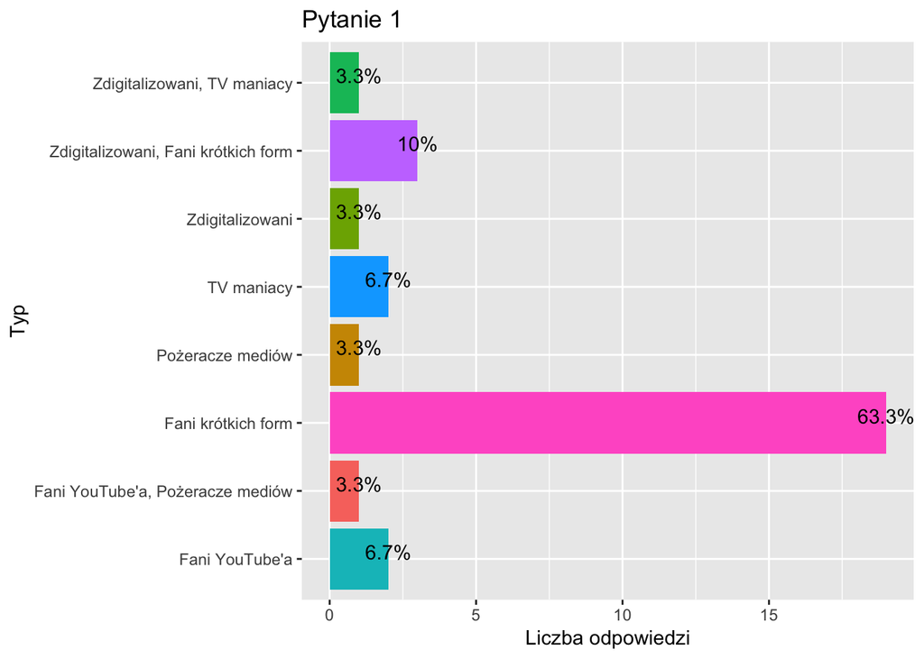

Poprawna odpowiedź to: Fani krótkich form (więcej niż połowa respondentów odpowiedziała poprawnie). Ale też były odpowiedzie dające do myślenia że może być 2 typy o takim samym udziale procentowym, mając największy udział. Wniosek z tego jest że z takiego kołowego wykresu nie da się zawsze stwierdzić gdzie jest największa grupa, co i jest wadą takiego wykresu.

## Pytanie 2

Czy są typy o tej samej liczności? Pytanie to bardzo podchwytliwe, bo nie ma takich typów. Tak, jest mała różnica między niektórymi typami, ale trudno ją zauważyć na wykresie kołowym.

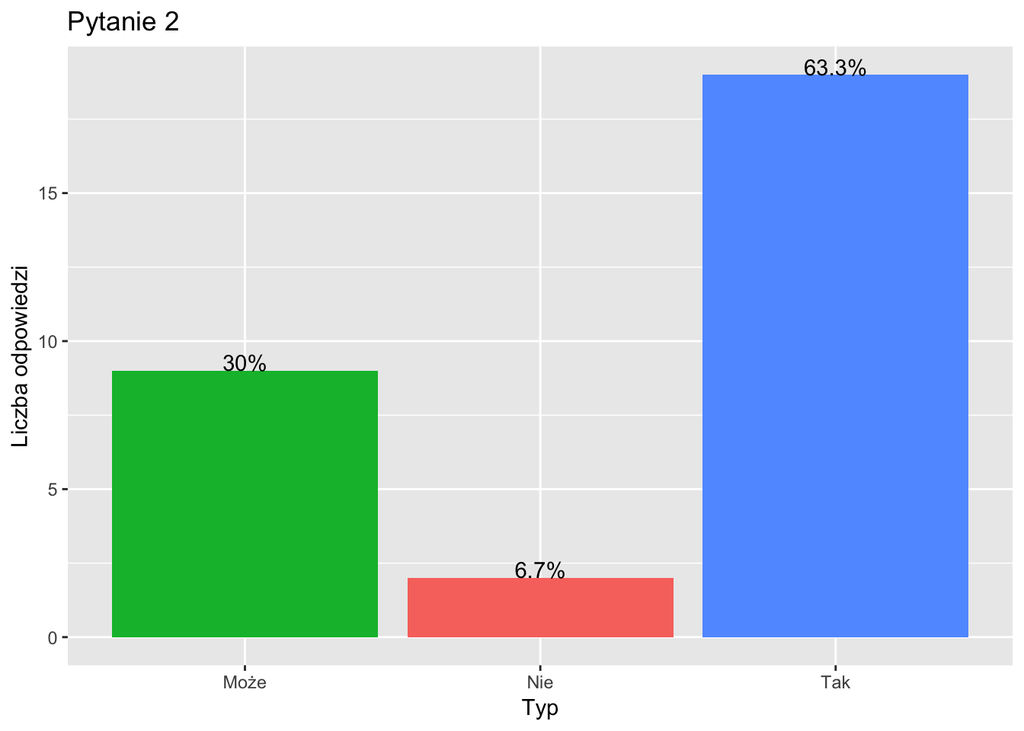

## Pytanie 3

Jeśli tak, to które? Pytanie było nie obowiązkowe, ale dużo osób znalazło typy o takim samym procentowym udziale. Było wybrane najciekawsze spotrzeżenie, że Fani krótkich form są o takim samym udziale procentowym jak Fani YouTube’a albo Zdigitalizowani. Ale z wykresu słupkowego wynika duża różnica między nimi.

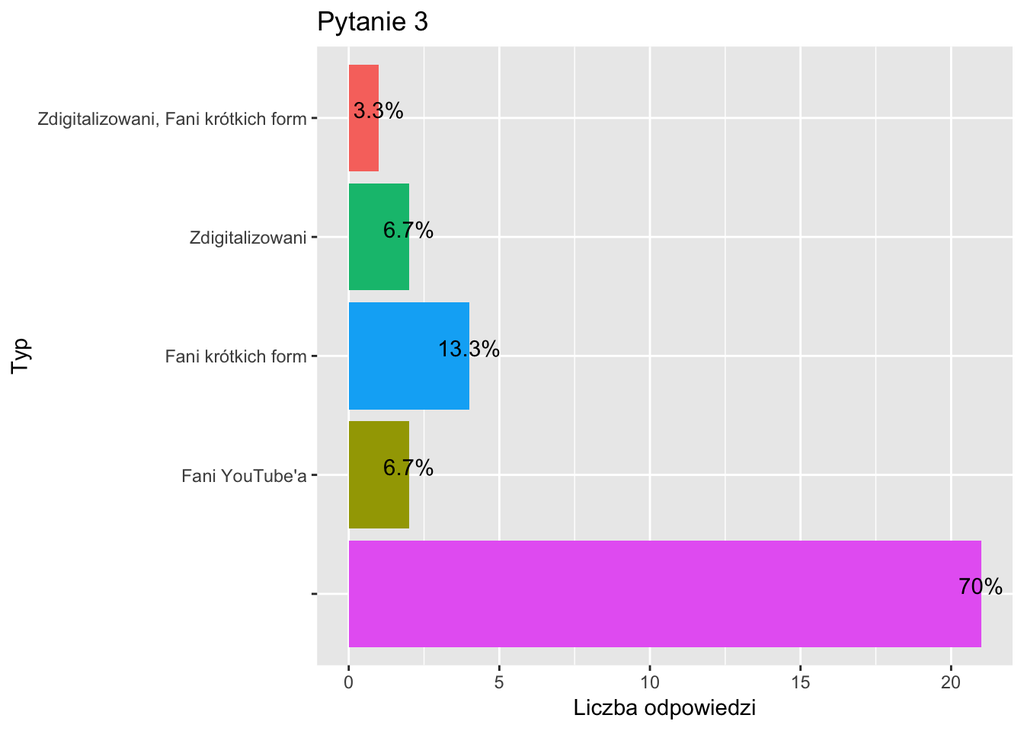

## Pytanie 4

Proszę posortować grupy nie rosnąco. Większość respondentów odpowiedziała w niepoprawnej kolejności. Wynika to z percepcji takiego wykresu kołowego 3D.

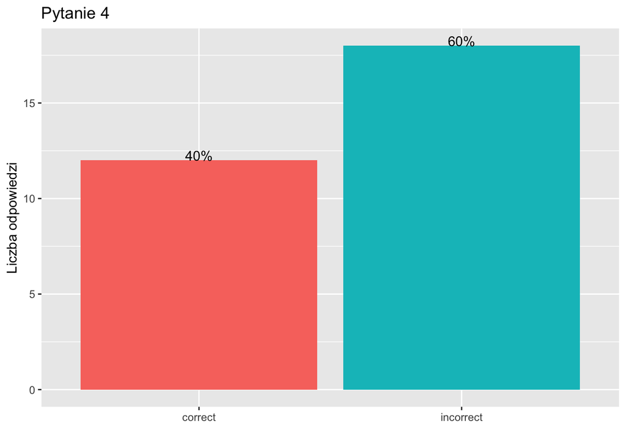

## Podsumowanie

Wyniki takiej ankiety potwierdzają tezę o tym że wykres kołowy 3D jest nieczytelny, i lepiej dla takich danych użyć wykresu słupkowego.